# **1. Forecasting urban floods**

*pitched by Samuel Barsanelli Costa | Data Science **batch #1643***

## **1.1. Problem statement**

What is an urban flood and why should we care about forecasting it?

📽️ A picture is worth a thousand words...

[video not shown]

This is a global issue related to climate change, as raised by the [UN](https://www.undrr.org/)'s [GAR23](https://www.undrr.org/gar/gar2023-special-report) report:

- the increase in the intensity of rainfall is already increasing flood risk 🌧️
- flood damage shall increase by **170%** with a global **2°C warming** 🔥

Additional regional conditions may intensify this effects, such as the El Niño that triggered [unprecedented flooding in the southern Brazilian state of Rio Grande do Sul](https://wmo.int/media/news/el-nino-linked-rains-trigger-devastation-brazil).

🌎 With the best **think globally, act locally** spirit in mind, this idea is scoped to predict flood in (yet to be defined) one among the most affected cities at the Porto Alegre Metro Area during the flooding events of April and May 2024

From a data science perpective, flood prediction is not new. The [Journal of Hydrology](https://www.sciencedirect.com/journal/journal-of-hydrology) alone has over 5k publications about it over the last 20 years.

Even Google has it's own AI model to predict daily flood. They've published their approach on a [paper](https://www.nature.com/articles/s41586-024-07145-1) in Nature, and made it online at the [Flood Hub](https://sites.research.google/floods/l/0/0/3) in 80+ countries.

[figure not shown]

But all resources available about flooding are way too much technical, not suited for the mainstream.

Could anyone quickly disgest this [data plot](https://app.powerbi.com/view?r=eyJrIjoiZTRjZDlmYjgtNzAzMS00ZTFmLTlmZDAtNzEwNjM0MDU0NTJhIiwidCI6ImUwYmI0MDEyLTgxMGItNDY5YS04YjRkLTY2N2ZjZDFiYWY4OCJ9) and make an informed "fight-or-flight" decision? 🤔

[figure not shown]

The driving questions of this idea are:

- can a classification model be trained to predict flood from rainfall data?
- how accurate could it be?
- how for in advance could we predict a flood (e.g. 5-day)?
- could we publish it in real-time in a easy-to-digest fashion?
- does it make sense to communicate just as we do with weather forecast?

💪 Let's work together for it!

[figure not shown]

## **1.2. Viability analysis**

To address this model we'll need, at least:

- **river stage data**: the measure of how high the level of the river is, at a certain location, in reference to a ground level (usually measured in cm). This is the target variable, the `y` 🎯
- **historical rainfall data**: the amount of rainfall at a certain location, measured as the amont of rainfall in a squared meter and reported as water height of that square (in mm). This is the exogenous variable, what [Darts](https://unit8co.github.io/darts/userguide/covariates.html) defines as `past covariates`.
- **future rainfall data**: this should be a reliable rainfall forecast source, in the same format as the historical data (measuring unit and sampling rate). This is what Darts defines as `future covariates`.

Automated Telemetry Stations comes out to the the best source for this goal, as it continuosly collect data at a certain timeframe (usually between 15 min and 60 min) and is less prone to human data collection errors.

One important thing to note is that rainfall is a spatially distributed fenomenon, so we should avoid relling on a single point-source for rain data. The area where all the water comes down to one single point is called watershed or [drainage basin](https://en.wikipedia.org/wiki/Drainage_basin). Note that it might not be raining at the very location of a flood, but all rain the poured down up in the mountains will flow over eventually and hit the lowest point. So the more rainfall stations we collect data from, within the drainage are, the best!

[figure not shown]

### **1.2.1. Data sources**

Here's the avaiable data from Automated Telemetry Stations and a reliable source for rainfall forecast.

| Data | Source | Format | Measuring unit | Sampling rate | Time span | URL |
| --- | --- | --- | --- | --- | --- | --- |
| River stage | SEMA/RS | xls | cm | 15 min | 2014 on | https://saladesituacao.rs.gov.br/dados |
| Past rainfall | SEMA/RS | xls | mm | 15 min | 2014 on | https://saladesituacao.rs.gov.br/dados |
| └────── | INMET | csv | mm | 1 hour | 2000 on | https://portal.inmet.gov.br/dadoshistoricos |
| Future rainfall | OpenWeather | API | mm | 3 hours | next 5 days | https://openweathermap.org/forecast5 |

📈 And here's a quick plot of a subset of the river stage and rainfall data from [São Leopoldo/RS station](https://saladesituacao.rs.gov.br/api/station/ana/sheet/87382000) at the Sinos River:

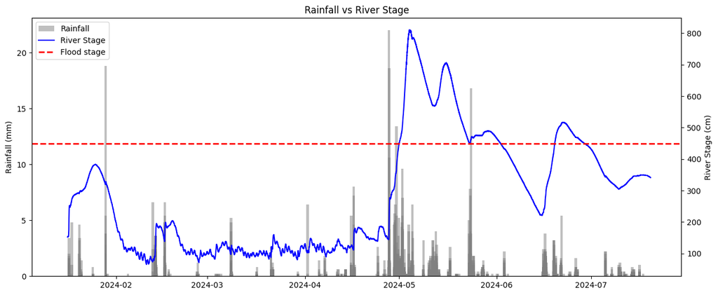

😮 It gets even more impressive when we accumulate rainfall over a moving window of 11 days (the time it takes for a raindrop from up top in the mountain to get all the way down to the flooding area).

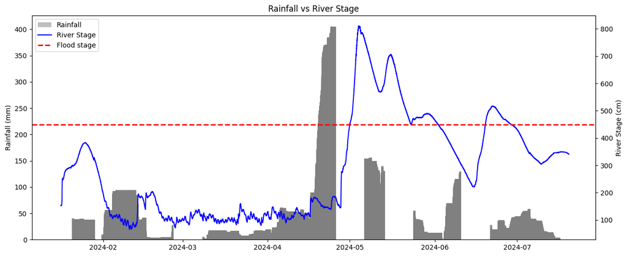